# Video Doesn’t Lie

## Acknowledgments

- [NSF BCS-1238599](http://www.nsf.gov/awardsearch/showAward?AWD_ID=1238599&HistoricalAwards=false)
- [NICHD U01-HD-076595](https://projectreporter.nih.gov/project_info_description.cfm?aid=8531595&icde=15908155&ddparam=&ddvalue=&ddsub=&cr=1&csb=default&cs=ASC)
- [Society for Research in Child Development (SRCD)](http://srcd.org)
- NYU Libraries, ITS, IRB, and OSP

## Is psychological science reproducible?

- Nosek et al. [(Collaboration 2015)](http://doi.org/10.1126/science.aac4716)
- vs. Gilbert et al. [(Gilbert et al. 2016)](http://doi.org/10.1126/science.aad7243)
- Sharing [data](https://osf.io/ezcuj/wiki/home/?_ga=1.260625677.1251838540.1458403228) focuses attention on substantive issues

[interactive chart not shown]

## [Databrary.org](http://databrary.org)

- Digital data library specialized for research video
- Video/audio + participant/context metadata
- Restricted access for research/educational use
- Policy framework for sharing identifiable data

## Video uniquely captures behavior

[video not shown]

## Video uniquely captures behavior

[video not shown]

https://nyu.databrary.org/slot/9840/-/asset/11193/download?inline=true

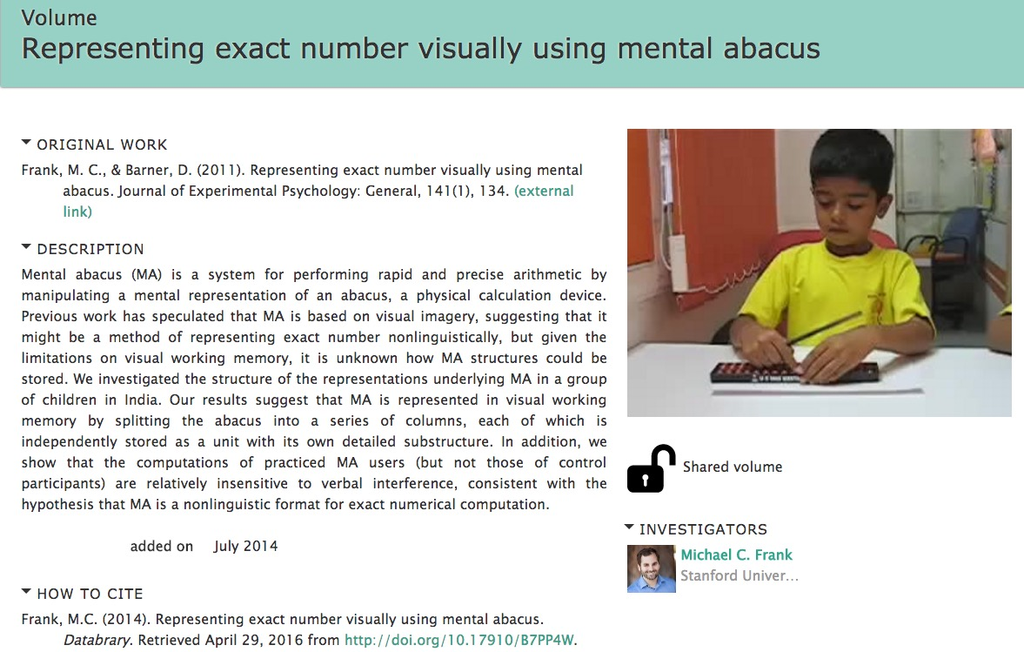

## Unequivocally & unambiguously demonstrates phenomena

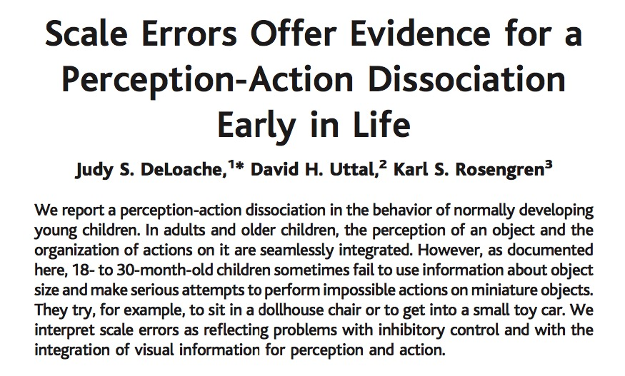

[(J. S. DeLoache, Uttal, and Rosengren 2004)](http://doi.org/10.1126/science.1093567)

[video not shown]

[(J. DeLoache 2014)](http://doi.org/10.17910/B7H019)

[interactive chart not shown]

## Video depicts unreported methodological details [(Adolph 2013)](http://dx.doi.org/10.17910/B7MW2K)

[video not shown]

## [Datavyu](http://datavyu.org) makes video coding reproducible

- Raw research video must be coded
- [Datavyu.org](http://datavyu.org) is a free, [open source](https://github.com/databrary/datavyu) coding tool
- Add codes, annotations time-locked to video segments
- Ruby API for [scripting](https://github.com/databrary/Datavyu-Example-Scripts)

[figure not shown]

## Reproducible video coding

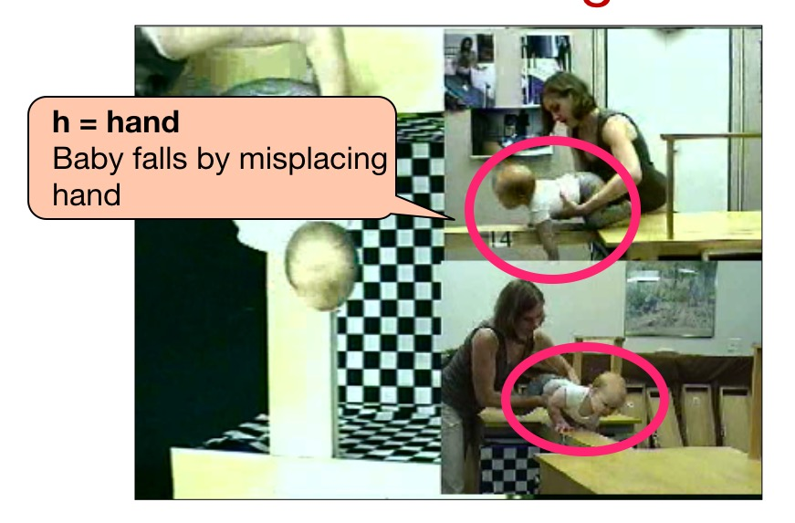

[(Adolph 2013)](http://dx.doi.org/10.17910/B7MW2K)

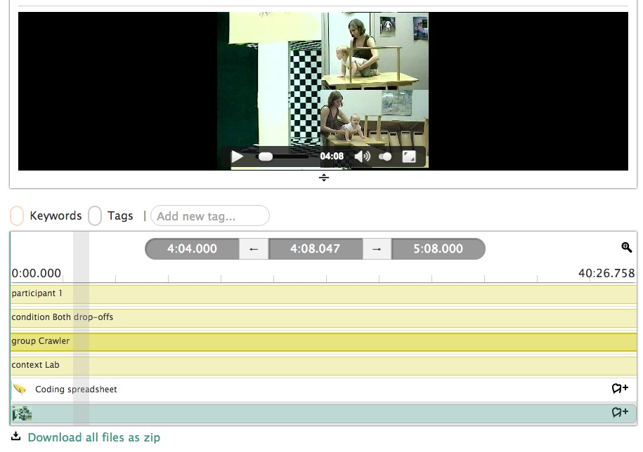

[(Adolph 2013)](http://dx.doi.org/10.17910/B7MW2K)

[figure not shown]

[(Adolph 2013)](http://dx.doi.org/10.17910/B7MW2K)

[figure not shown]

[(Adolph 2013)](http://dx.doi.org/10.17910/B7MW2K)

## Securing permission to share while limiting access

[video not shown]

## Databrary enhances reproducibility

- "Active" curation of data **as it is collected**
- Organize, share, standardized participant metadata
- Sharing based on
  - user access level
  - participant permission

## [(Adolph 2013)](http://dx.doi.org/10.17910/B7MW2K)

[interactive chart not shown]

## Databrary enhances reproducibility

- Share raw research videos
- Share video excerpts for teaching and learning
- Share materials, coding spreadsheets, displays
- Share links to papers, code repositories
- Shared datasets get DOIs
- Long-term preservation via partnership with NYU Libraries

## Take homes

- Video uniquely captures complexity & richness of behavior
- Databrary securely stores, shares video
- Databrary and Datavyu enhance reproducibility of video-based research
- Databrary makes psychological science more transparent & reproducible

## References

Adolph, Karen; 2013. “Infants Crawling and Walking over High and Low Bridges.” Databrary. doi:10.17910/B7MW2K.

DeLoache, Judy. 2014. “Scale Errors Offer Evidence for a Perception-Action Dissociation Early in Life.” Databrary. doi:10.17910/B7H019.

DeLoache, Judy S., David H. Uttal, and Karl S. Rosengren. 2004. “Scale Errors Offer Evidence for a Perception-Action Dissociation Early in Life.” *Science* 304 (5673): 1027–9. doi:10.1126/science.1093567.

Frank, Michael C.; 2014. “Representing Exact Number Visually Using Mental Abacus.” Databrary. doi:10.17910/B7PP4W.

Gilbert, Daniel T., Gary King, Stephen Pettigrew, and Timothy D. Wilson. 2016. “Comment on ‘Estimating the Reproducibility of Psychological Science’.” *Science* 351 (6277): 1037–7. doi:10.1126/science.aad7243.